# Risk Factor Analysis

## Outcome Variable

**Outcome Variable:** y_rate_len

## Predictor Variables

**Intervention Variable:** parity

**Adjustment Set:**

- arm
- W_mage
- meducyrs
- feducyrs
- W_mhtcm
- W_mwtkg
- W_mbmi
- vagbrth
- single
- delta_W_mage
- delta_meducyrs
- delta_feducyrs
- delta_W_mhtcm
- delta_W_mwtkg
- delta_W_mbmi
- delta_vagbrth
- delta_single

## Stratifying Variables

The analysis was stratified on these variable(s):

- agecat
- studyid
- country

## Data Summary

| agecat | studyid | country | parity | n_cell | n |
| --- | --- | --- | --- | --- | --- |
| 0-3 months | COHORTS | GUATEMALA | 1 | 93 | 728 |
| 0-3 months | COHORTS | GUATEMALA | 2 | 111 | 728 |
| 0-3 months | COHORTS | GUATEMALA | 3+ | 524 | 728 |
| 0-3 months | COHORTS | INDIA | 1 | 671 | 4021 |
| 0-3 months | COHORTS | INDIA | 2 | 1015 | 4021 |
| 0-3 months | COHORTS | INDIA | 3+ | 2335 | 4021 |
| 0-3 months | GMS-Nepal | NEPAL | 1 | 137 | 509 |
| 0-3 months | GMS-Nepal | NEPAL | 2 | 129 | 509 |
| 0-3 months | GMS-Nepal | NEPAL | 3+ | 243 | 509 |
| 0-3 months | JiVitA-3 | BANGLADESH | 1 | 6338 | 19878 |
| 0-3 months | JiVitA-3 | BANGLADESH | 2 | 6881 | 19878 |
| 0-3 months | JiVitA-3 | BANGLADESH | 3+ | 6659 | 19878 |
| 0-3 months | Keneba | GAMBIA | 1 | 130 | 1145 |
| 0-3 months | Keneba | GAMBIA | 2 | 113 | 1145 |
| 0-3 months | Keneba | GAMBIA | 3+ | 902 | 1145 |
| 0-3 months | PROVIDE | BANGLADESH | 1 | 242 | 640 |
| 0-3 months | PROVIDE | BANGLADESH | 2 | 226 | 640 |
| 0-3 months | PROVIDE | BANGLADESH | 3+ | 172 | 640 |
| 0-3 months | SAS-CompFeed | INDIA | 1 | 344 | 1261 |
| 0-3 months | SAS-CompFeed | INDIA | 2 | 298 | 1261 |
| 0-3 months | SAS-CompFeed | INDIA | 3+ | 619 | 1261 |
| 0-3 months | ZVITAMBO | ZIMBABWE | 1 | 3100 | 7981 |
| 0-3 months | ZVITAMBO | ZIMBABWE | 2 | 2478 | 7981 |
| 0-3 months | ZVITAMBO | ZIMBABWE | 3+ | 2403 | 7981 |
| 3-6 months | COHORTS | GUATEMALA | 1 | 107 | 805 |
| 3-6 months | COHORTS | GUATEMALA | 2 | 114 | 805 |
| 3-6 months | COHORTS | GUATEMALA | 3+ | 584 | 805 |
| 3-6 months | COHORTS | INDIA | 1 | 675 | 4069 |
| 3-6 months | COHORTS | INDIA | 2 | 1042 | 4069 |
| 3-6 months | COHORTS | INDIA | 3+ | 2352 | 4069 |

[output cut: 156 more lines]

The following strata were considered:

- agecat: 0-3 months, studyid: COHORTS, country: GUATEMALA
- agecat: 0-3 months, studyid: COHORTS, country: INDIA
- agecat: 0-3 months, studyid: GMS-Nepal, country: NEPAL
- agecat: 0-3 months, studyid: JiVitA-3, country: BANGLADESH
- agecat: 0-3 months, studyid: Keneba, country: GAMBIA
- agecat: 0-3 months, studyid: PROVIDE, country: BANGLADESH
- agecat: 0-3 months, studyid: SAS-CompFeed, country: INDIA
- agecat: 0-3 months, studyid: ZVITAMBO, country: ZIMBABWE
- agecat: 12-15 months, studyid: COHORTS, country: GUATEMALA
- agecat: 12-15 months, studyid: GMS-Nepal, country: NEPAL
- agecat: 12-15 months, studyid: Keneba, country: GAMBIA
- agecat: 12-15 months, studyid: PROVIDE, country: BANGLADESH
- agecat: 12-15 months, studyid: SAS-CompFeed, country: INDIA
- agecat: 12-15 months, studyid: SAS-FoodSuppl, country: INDIA
- agecat: 12-15 months, studyid: TanzaniaChild2, country: TANZANIA, UNITED REPUBLIC OF
- agecat: 12-15 months, studyid: ZVITAMBO, country: ZIMBABWE
- agecat: 15-18 months, studyid: COHORTS, country: GUATEMALA
- agecat: 15-18 months, studyid: GMS-Nepal, country: NEPAL
- agecat: 15-18 months, studyid: Keneba, country: GAMBIA
- agecat: 15-18 months, studyid: PROVIDE, country: BANGLADESH
- agecat: 15-18 months, studyid: SAS-CompFeed, country: INDIA
- agecat: 15-18 months, studyid: SAS-FoodSuppl, country: INDIA
- agecat: 15-18 months, studyid: TanzaniaChild2, country: TANZANIA, UNITED REPUBLIC OF
- agecat: 15-18 months, studyid: ZVITAMBO, country: ZIMBABWE
- agecat: 18-21 months, studyid: COHORTS, country: GUATEMALA
- agecat: 18-21 months, studyid: GMS-Nepal, country: NEPAL
- agecat: 18-21 months, studyid: Keneba, country: GAMBIA
- agecat: 18-21 months, studyid: PROVIDE, country: BANGLADESH
- agecat: 18-21 months, studyid: TanzaniaChild2, country: TANZANIA, UNITED REPUBLIC OF
- agecat: 18-21 months, studyid: ZVITAMBO, country: ZIMBABWE
- agecat: 21-24 months, studyid: COHORTS, country: GUATEMALA
- agecat: 21-24 months, studyid: GMS-Nepal, country: NEPAL
- agecat: 21-24 months, studyid: Keneba, country: GAMBIA
- agecat: 21-24 months, studyid: PROVIDE, country: BANGLADESH
- agecat: 21-24 months, studyid: ZVITAMBO, country: ZIMBABWE
- agecat: 3-6 months, studyid: COHORTS, country: GUATEMALA
- agecat: 3-6 months, studyid: COHORTS, country: INDIA
- agecat: 3-6 months, studyid: GMS-Nepal, country: NEPAL
- agecat: 3-6 months, studyid: JiVitA-3, country: BANGLADESH
- agecat: 3-6 months, studyid: Keneba, country: GAMBIA
- agecat: 3-6 months, studyid: PROVIDE, country: BANGLADESH
- agecat: 3-6 months, studyid: SAS-CompFeed, country: INDIA
- agecat: 3-6 months, studyid: TanzaniaChild2, country: TANZANIA, UNITED REPUBLIC OF
- agecat: 3-6 months, studyid: ZVITAMBO, country: ZIMBABWE
- agecat: 6-9 months, studyid: COHORTS, country: GUATEMALA
- agecat: 6-9 months, studyid: COHORTS, country: INDIA
- agecat: 6-9 months, studyid: GMS-Nepal, country: NEPAL
- agecat: 6-9 months, studyid: Keneba, country: GAMBIA
- agecat: 6-9 months, studyid: PROVIDE, country: BANGLADESH
- agecat: 6-9 months, studyid: SAS-CompFeed, country: INDIA
- agecat: 6-9 months, studyid: SAS-FoodSuppl, country: INDIA
- agecat: 6-9 months, studyid: TanzaniaChild2, country: TANZANIA, UNITED REPUBLIC OF
- agecat: 6-9 months, studyid: ZVITAMBO, country: ZIMBABWE
- agecat: 9-12 months, studyid: COHORTS, country: GUATEMALA
- agecat: 9-12 months, studyid: COHORTS, country: INDIA
- agecat: 9-12 months, studyid: GMS-Nepal, country: NEPAL
- agecat: 9-12 months, studyid: Keneba, country: GAMBIA
- agecat: 9-12 months, studyid: PROVIDE, country: BANGLADESH
- agecat: 9-12 months, studyid: SAS-CompFeed, country: INDIA
- agecat: 9-12 months, studyid: SAS-FoodSuppl, country: INDIA
- agecat: 9-12 months, studyid: TanzaniaChild2, country: TANZANIA, UNITED REPUBLIC OF
- agecat: 9-12 months, studyid: ZVITAMBO, country: ZIMBABWE

### Dropped Strata

Some strata were dropped due to rare outcomes:

- agecat: 6-9 months, studyid: SAS-FoodSuppl, country: INDIA
- agecat: 9-12 months, studyid: SAS-FoodSuppl, country: INDIA
- agecat: 12-15 months, studyid: SAS-FoodSuppl, country: INDIA
- agecat: 15-18 months, studyid: SAS-FoodSuppl, country: INDIA
- agecat: 18-21 months, studyid: TanzaniaChild2, country: TANZANIA, UNITED REPUBLIC OF

## Methods Detail

We’re interested in the causal parameters $E[Y_a]$ for all values of $a \in \mathcal{A}$. These parameters represent the mean outcome if, possibly contrary to fact, we intervened to set all units to have $A=a$. Under the randomization and positivity assumptions, these are identified by the statistical parameters $\psi_a=E_W[E_{Y|A,W}(Y|A=a,W)]$. In addition, we’re interested in the mean of $Y$, $E[Y]$ under no intervention (the observed mean). We will estimate these parameters by using SuperLearner to fit the relevant likelihood factors – $E_{Y|A,W}(Y|A=a,W)$ and $p(A=a|W)$, and then updating our likelihood fit using a joint TMLE.

For unadjusted analyses ($W=\{\}$), initial likelihoods were estimated using Lrnr_glm to estimate the simple $E(Y|A)$ and Lrnr_mean to estimate $p(A)$. For adjusted analyses, a small library containing Lrnr_glmnet, Lrnr_xgboost, and Lrnr_mean was used.

Having estimated these parameters, we will then use the delta method to estimate relative risks and attributable risks relative to a prespecified baseline level of $A$.

# Results Detail

## Results Plots

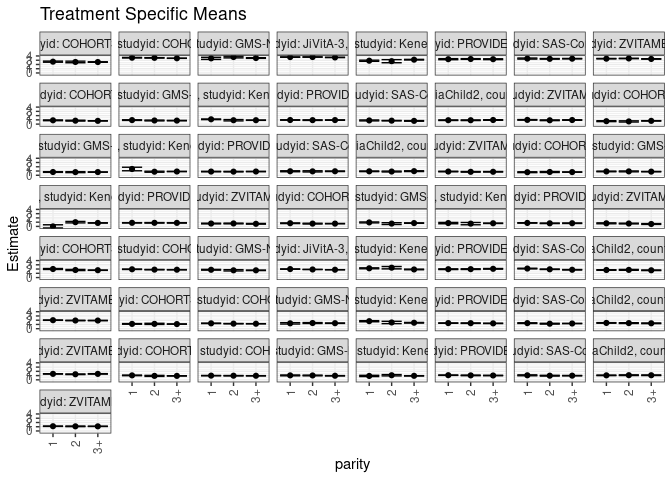

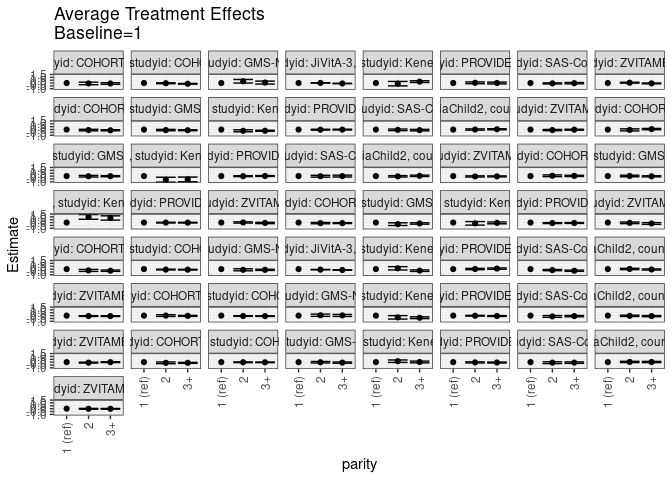

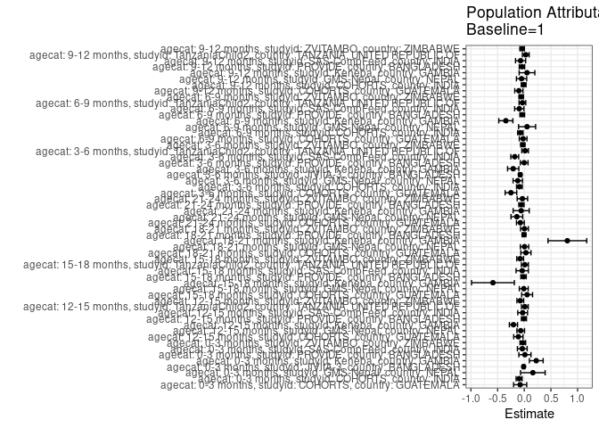

## Results Table

### Parameter: TSM

| agecat | studyid | country | intervention_level | baseline_level | estimate | ci_lower | ci_upper |
| --- | --- | --- | --- | --- | --- | --- | --- |
| 0-3 months | COHORTS | GUATEMALA | 1 | NA | 2.6601187 | 2.5355314 | 2.7847060 |
| 0-3 months | COHORTS | GUATEMALA | 2 | NA | 2.5904276 | 2.4075645 | 2.7732907 |
| 0-3 months | COHORTS | GUATEMALA | 3+ | NA | 2.5733922 | 2.5160579 | 2.6307265 |
| 0-3 months | COHORTS | INDIA | 1 | NA | 3.5922209 | 3.5339161 | 3.6505258 |
| 0-3 months | COHORTS | INDIA | 2 | NA | 3.5595259 | 3.5066810 | 3.6123708 |
| 0-3 months | COHORTS | INDIA | 3+ | NA | 3.4583610 | 3.4320362 | 3.4846857 |
| 0-3 months | GMS-Nepal | NEPAL | 1 | NA | 3.4377589 | 3.1955486 | 3.6799692 |
| 0-3 months | GMS-Nepal | NEPAL | 2 | NA | 3.7481520 | 3.5533595 | 3.9429445 |
| 0-3 months | GMS-Nepal | NEPAL | 3+ | NA | 3.5165152 | 3.4459882 | 3.5870422 |
| 0-3 months | JiVitA-3 | BANGLADESH | 1 | NA | 3.7348380 | 3.7111069 | 3.7585690 |
| 0-3 months | JiVitA-3 | BANGLADESH | 2 | NA | 3.7502455 | 3.7277605 | 3.7727304 |
| 0-3 months | JiVitA-3 | BANGLADESH | 3+ | NA | 3.6558407 | 3.6324218 | 3.6792597 |
| 0-3 months | Keneba | GAMBIA | 1 | NA | 2.8853409 | 2.7554529 | 3.0152289 |
| 0-3 months | Keneba | GAMBIA | 2 | NA | 2.7756952 | 2.4093486 | 3.1420417 |
| 0-3 months | Keneba | GAMBIA | 3+ | NA | 3.1284014 | 3.0602618 | 3.1965411 |
| 0-3 months | PROVIDE | BANGLADESH | 1 | NA | 3.2456569 | 3.1208275 | 3.3704862 |
| 0-3 months | PROVIDE | BANGLADESH | 2 | NA | 3.2853197 | 3.1979729 | 3.3726666 |
| 0-3 months | PROVIDE | BANGLADESH | 3+ | NA | 3.2443317 | 3.1463585 | 3.3423050 |
| 0-3 months | SAS-CompFeed | INDIA | 1 | NA | 3.3886732 | 3.2708491 | 3.5064973 |
| 0-3 months | SAS-CompFeed | INDIA | 2 | NA | 3.3257660 | 3.2491826 | 3.4023495 |
| 0-3 months | SAS-CompFeed | INDIA | 3+ | NA | 3.3618454 | 3.3094806 | 3.4142102 |
| 0-3 months | ZVITAMBO | ZIMBABWE | 1 | NA | 3.3638714 | 3.3071750 | 3.4205678 |
| 0-3 months | ZVITAMBO | ZIMBABWE | 2 | NA | 3.4174505 | 3.3606960 | 3.4742050 |
| 0-3 months | ZVITAMBO | ZIMBABWE | 3+ | NA | 3.2994504 | 3.2486107 | 3.3502900 |
| 3-6 months | COHORTS | GUATEMALA | 1 | NA | 2.0115610 | 1.9010332 | 2.1220888 |
| 3-6 months | COHORTS | GUATEMALA | 2 | NA | 1.7784487 | 1.6453596 | 1.9115378 |
| 3-6 months | COHORTS | GUATEMALA | 3+ | NA | 1.7306441 | 1.6872946 | 1.7739936 |
| 3-6 months | COHORTS | INDIA | 1 | NA | 1.9470783 | 1.8908213 | 2.0033353 |
| 3-6 months | COHORTS | INDIA | 2 | NA | 1.8646143 | 1.8217274 | 1.9075011 |
| 3-6 months | COHORTS | INDIA | 3+ | NA | 1.8462990 | 1.8215630 | 1.8710351 |

[output cut: 141 more lines]

### Parameter: E(Y)

| agecat | studyid | country | intervention_level | baseline_level | estimate | ci_lower | ci_upper |
| --- | --- | --- | --- | --- | --- | --- | --- |
| 0-3 months | COHORTS | GUATEMALA | NA | NA | 2.5828382 | 2.5396287 | 2.6260477 |
| 0-3 months | COHORTS | INDIA | NA | NA | 3.4951636 | 3.4771029 | 3.5132243 |
| 0-3 months | GMS-Nepal | NEPAL | NA | NA | 3.5989683 | 3.5479067 | 3.6500300 |
| 0-3 months | JiVitA-3 | BANGLADESH | NA | NA | 3.7233830 | 3.7130769 | 3.7336890 |
| 0-3 months | Keneba | GAMBIA | NA | NA | 3.1106299 | 3.0607110 | 3.1605487 |
| 0-3 months | PROVIDE | BANGLADESH | NA | NA | 3.2576810 | 3.2206777 | 3.2946843 |
| 0-3 months | SAS-CompFeed | INDIA | NA | NA | 3.3515606 | 3.2984055 | 3.4047158 |
| 0-3 months | ZVITAMBO | ZIMBABWE | NA | NA | 3.3370118 | 3.3164684 | 3.3575551 |
| 3-6 months | COHORTS | GUATEMALA | NA | NA | 1.7616932 | 1.7309393 | 1.7924472 |
| 3-6 months | COHORTS | INDIA | NA | NA | 1.8562696 | 1.8412447 | 1.8712944 |
| 3-6 months | GMS-Nepal | NEPAL | NA | NA | 1.7095685 | 1.6702436 | 1.7488934 |
| 3-6 months | JiVitA-3 | BANGLADESH | NA | NA | 1.9202003 | 1.9097349 | 1.9306657 |
| 3-6 months | Keneba | GAMBIA | NA | NA | 1.9715566 | 1.9280386 | 2.0150747 |
| 3-6 months | PROVIDE | BANGLADESH | NA | NA | 1.9657457 | 1.9318660 | 1.9996254 |
| 3-6 months | SAS-CompFeed | INDIA | NA | NA | 1.9406419 | 1.8967379 | 1.9845458 |
| 3-6 months | TanzaniaChild2 | TANZANIA, UNITED REPUBLIC OF | NA | NA | 1.7960345 | 1.7599951 | 1.8320738 |
| 3-6 months | ZVITAMBO | ZIMBABWE | NA | NA | 1.9753863 | 1.9557273 | 1.9950453 |
| 6-9 months | COHORTS | GUATEMALA | NA | NA | 1.1069375 | 1.0799105 | 1.1339645 |
| 6-9 months | COHORTS | INDIA | NA | NA | 1.1876267 | 1.1734988 | 1.2017547 |
| 6-9 months | GMS-Nepal | NEPAL | NA | NA | 1.3172026 | 1.2765236 | 1.3578817 |
| 6-9 months | Keneba | GAMBIA | NA | NA | 1.4249547 | 1.3698531 | 1.4800562 |
| 6-9 months | PROVIDE | BANGLADESH | NA | NA | 1.2824185 | 1.2571827 | 1.3076542 |
| 6-9 months | SAS-CompFeed | INDIA | NA | NA | 1.2164378 | 1.1971945 | 1.2356811 |
| 6-9 months | TanzaniaChild2 | TANZANIA, UNITED REPUBLIC OF | NA | NA | 1.3229826 | 1.2861186 | 1.3598466 |
| 6-9 months | ZVITAMBO | ZIMBABWE | NA | NA | 1.3469775 | 1.3279219 | 1.3660330 |
| 9-12 months | COHORTS | GUATEMALA | NA | NA | 0.9507015 | 0.9262928 | 0.9751103 |
| 9-12 months | COHORTS | INDIA | NA | NA | 0.9788325 | 0.9636749 | 0.9939901 |
| 9-12 months | GMS-Nepal | NEPAL | NA | NA | 0.9983761 | 0.9658898 | 1.0308625 |
| 9-12 months | Keneba | GAMBIA | NA | NA | 0.9677634 | 0.9232065 | 1.0123204 |
| 9-12 months | PROVIDE | BANGLADESH | NA | NA | 1.0499750 | 1.0230130 | 1.0769370 |
| 9-12 months | SAS-CompFeed | INDIA | NA | NA | 0.9997324 | 0.9682232 | 1.0312416 |
| 9-12 months | TanzaniaChild2 | TANZANIA, UNITED REPUBLIC OF | NA | NA | 1.0872065 | 1.0529274 | 1.1214857 |
| 9-12 months | ZVITAMBO | ZIMBABWE | NA | NA | 1.0812148 | 1.0633428 | 1.0990869 |
| 12-15 months | COHORTS | GUATEMALA | NA | NA | 0.7856579 | 0.7592765 | 0.8120393 |
| 12-15 months | GMS-Nepal | NEPAL | NA | NA | 0.8797046 | 0.8507834 | 0.9086259 |
| 12-15 months | Keneba | GAMBIA | NA | NA | 0.9311532 | 0.8983800 | 0.9639264 |
| 12-15 months | PROVIDE | BANGLADESH | NA | NA | 0.9597501 | 0.9335899 | 0.9859102 |
| 12-15 months | SAS-CompFeed | INDIA | NA | NA | 0.8334688 | 0.7956713 | 0.8712664 |
| 12-15 months | TanzaniaChild2 | TANZANIA, UNITED REPUBLIC OF | NA | NA | 0.9308176 | 0.8938698 | 0.9677654 |
| 12-15 months | ZVITAMBO | ZIMBABWE | NA | NA | 0.9205920 | 0.8936831 | 0.9475009 |
| 15-18 months | COHORTS | GUATEMALA | NA | NA | 0.7458835 | 0.7161259 | 0.7756412 |
| 15-18 months | GMS-Nepal | NEPAL | NA | NA | 0.7549520 | 0.7202105 | 0.7896934 |
| 15-18 months | Keneba | GAMBIA | NA | NA | 0.8874581 | 0.8529191 | 0.9219971 |
| 15-18 months | PROVIDE | BANGLADESH | NA | NA | 0.8560998 | 0.8320145 | 0.8801852 |
| 15-18 months | SAS-CompFeed | INDIA | NA | NA | 0.9046837 | 0.8805433 | 0.9288241 |
| 15-18 months | TanzaniaChild2 | TANZANIA, UNITED REPUBLIC OF | NA | NA | 0.9386381 | 0.8958056 | 0.9814706 |
| 15-18 months | ZVITAMBO | ZIMBABWE | NA | NA | 0.7994243 | 0.7694755 | 0.8293732 |
| 18-21 months | COHORTS | GUATEMALA | NA | NA | 0.7491980 | 0.7206457 | 0.7777504 |
| 18-21 months | GMS-Nepal | NEPAL | NA | NA | 0.9038955 | 0.8699458 | 0.9378453 |
| 18-21 months | Keneba | GAMBIA | NA | NA | 0.8148545 | 0.7779341 | 0.8517749 |
| 18-21 months | PROVIDE | BANGLADESH | NA | NA | 0.8393377 | 0.8153485 | 0.8633269 |
| 18-21 months | ZVITAMBO | ZIMBABWE | NA | NA | 0.6808824 | 0.6468583 | 0.7149065 |
| 21-24 months | COHORTS | GUATEMALA | NA | NA | 0.6777084 | 0.6544850 | 0.7009317 |
| 21-24 months | GMS-Nepal | NEPAL | NA | NA | 0.7990312 | 0.7536798 | 0.8443825 |
| 21-24 months | Keneba | GAMBIA | NA | NA | 0.7279143 | 0.6917604 | 0.7640682 |
| 21-24 months | PROVIDE | BANGLADESH | NA | NA | 0.7631391 | 0.7377453 | 0.7885328 |
| 21-24 months | ZVITAMBO | ZIMBABWE | NA | NA | 0.6907415 | 0.6526782 | 0.7288047 |

### Parameter: ATE

| agecat | studyid | country | intervention_level | baseline_level | estimate | ci_lower | ci_upper |
| --- | --- | --- | --- | --- | --- | --- | --- |
| 0-3 months | COHORTS | GUATEMALA | 1 | 1 | 0.0000000 | 0.0000000 | 0.0000000 |
| 0-3 months | COHORTS | GUATEMALA | 2 | 1 | -0.0696911 | -0.2913703 | 0.1519881 |
| 0-3 months | COHORTS | GUATEMALA | 3+ | 1 | -0.0867266 | -0.2236469 | 0.0501938 |
| 0-3 months | COHORTS | INDIA | 1 | 1 | 0.0000000 | 0.0000000 | 0.0000000 |
| 0-3 months | COHORTS | INDIA | 2 | 1 | -0.0326950 | -0.1113666 | 0.0459765 |
| 0-3 months | COHORTS | INDIA | 3+ | 1 | -0.1338600 | -0.1977866 | -0.0699333 |
| 0-3 months | GMS-Nepal | NEPAL | 1 | 1 | 0.0000000 | 0.0000000 | 0.0000000 |
| 0-3 months | GMS-Nepal | NEPAL | 2 | 1 | 0.3103930 | -0.0017357 | 0.6225218 |
| 0-3 months | GMS-Nepal | NEPAL | 3+ | 1 | 0.0787563 | -0.1736994 | 0.3312120 |
| 0-3 months | JiVitA-3 | BANGLADESH | 1 | 1 | 0.0000000 | 0.0000000 | 0.0000000 |
| 0-3 months | JiVitA-3 | BANGLADESH | 2 | 1 | 0.0154075 | -0.0161887 | 0.0470037 |
| 0-3 months | JiVitA-3 | BANGLADESH | 3+ | 1 | -0.0789972 | -0.1128288 | -0.0451657 |
| 0-3 months | Keneba | GAMBIA | 1 | 1 | 0.0000000 | 0.0000000 | 0.0000000 |
| 0-3 months | Keneba | GAMBIA | 2 | 1 | -0.1096457 | -0.4973815 | 0.2780900 |
| 0-3 months | Keneba | GAMBIA | 3+ | 1 | 0.2430605 | 0.0970312 | 0.3890899 |
| 0-3 months | PROVIDE | BANGLADESH | 1 | 1 | 0.0000000 | 0.0000000 | 0.0000000 |
| 0-3 months | PROVIDE | BANGLADESH | 2 | 1 | 0.0396629 | -0.1123262 | 0.1916520 |
| 0-3 months | PROVIDE | BANGLADESH | 3+ | 1 | -0.0013251 | -0.1602769 | 0.1576266 |
| 0-3 months | SAS-CompFeed | INDIA | 1 | 1 | 0.0000000 | 0.0000000 | 0.0000000 |
| 0-3 months | SAS-CompFeed | INDIA | 2 | 1 | -0.0629072 | -0.1574654 | 0.0316511 |
| 0-3 months | SAS-CompFeed | INDIA | 3+ | 1 | -0.0268278 | -0.1404186 | 0.0867630 |
| 0-3 months | ZVITAMBO | ZIMBABWE | 1 | 1 | 0.0000000 | 0.0000000 | 0.0000000 |
| 0-3 months | ZVITAMBO | ZIMBABWE | 2 | 1 | 0.0535791 | -0.0265496 | 0.1337078 |
| 0-3 months | ZVITAMBO | ZIMBABWE | 3+ | 1 | -0.0644210 | -0.1404946 | 0.0116526 |
| 3-6 months | COHORTS | GUATEMALA | 1 | 1 | 0.0000000 | 0.0000000 | 0.0000000 |
| 3-6 months | COHORTS | GUATEMALA | 2 | 1 | -0.2331122 | -0.4062563 | -0.0599681 |
| 3-6 months | COHORTS | GUATEMALA | 3+ | 1 | -0.2809169 | -0.3996268 | -0.1622070 |
| 3-6 months | COHORTS | INDIA | 1 | 1 | 0.0000000 | 0.0000000 | 0.0000000 |
| 3-6 months | COHORTS | INDIA | 2 | 1 | -0.0824640 | -0.1531544 | -0.0117736 |
| 3-6 months | COHORTS | INDIA | 3+ | 1 | -0.1007793 | -0.1622329 | -0.0393256 |

[output cut: 141 more lines]

### Parameter: PAR

| agecat | studyid | country | intervention_level | baseline_level | estimate | ci_lower | ci_upper |
| --- | --- | --- | --- | --- | --- | --- | --- |
| 0-3 months | COHORTS | GUATEMALA | 1 | NA | -0.0772805 | -0.2003889 | 0.0458279 |
| 0-3 months | COHORTS | INDIA | 1 | NA | -0.0970573 | -0.1533987 | -0.0407159 |
| 0-3 months | GMS-Nepal | NEPAL | 1 | NA | 0.1612094 | -0.0695061 | 0.3919248 |
| 0-3 months | JiVitA-3 | BANGLADESH | 1 | NA | -0.0114550 | -0.0339461 | 0.0110361 |
| 0-3 months | Keneba | GAMBIA | 1 | NA | 0.2252890 | 0.0958976 | 0.3546804 |
| 0-3 months | PROVIDE | BANGLADESH | 1 | NA | 0.0120242 | -0.1020005 | 0.1260489 |
| 0-3 months | SAS-CompFeed | INDIA | 1 | NA | -0.0371126 | -0.1286287 | 0.0544036 |
| 0-3 months | ZVITAMBO | ZIMBABWE | 1 | NA | -0.0268597 | -0.0800762 | 0.0263569 |
| 3-6 months | COHORTS | GUATEMALA | 1 | NA | -0.2498677 | -0.3586203 | -0.1411152 |
| 3-6 months | COHORTS | INDIA | 1 | NA | -0.0908087 | -0.1448574 | -0.0367600 |
| 3-6 months | GMS-Nepal | NEPAL | 1 | NA | -0.1219742 | -0.2099790 | -0.0339694 |
| 3-6 months | JiVitA-3 | BANGLADESH | 1 | NA | -0.0751043 | -0.1025195 | -0.0476890 |
| 3-6 months | Keneba | GAMBIA | 1 | NA | -0.2074376 | -0.3134008 | -0.1014743 |
| 3-6 months | PROVIDE | BANGLADESH | 1 | NA | -0.0016447 | -0.0738264 | 0.0705370 |
| 3-6 months | SAS-CompFeed | INDIA | 1 | NA | -0.1784479 | -0.2520172 | -0.1048785 |
| 3-6 months | TanzaniaChild2 | TANZANIA, UNITED REPUBLIC OF | 1 | NA | 0.0157822 | -0.0462458 | 0.0778102 |
| 3-6 months | ZVITAMBO | ZIMBABWE | 1 | NA | -0.0273812 | -0.0680240 | 0.0132616 |
| 6-9 months | COHORTS | GUATEMALA | 1 | NA | -0.0211050 | -0.0930384 | 0.0508284 |
| 6-9 months | COHORTS | INDIA | 1 | NA | -0.0731209 | -0.1232293 | -0.0230124 |
| 6-9 months | GMS-Nepal | NEPAL | 1 | NA | 0.0528404 | -0.1069785 | 0.2126593 |
| 6-9 months | Keneba | GAMBIA | 1 | NA | -0.3456043 | -0.4780343 | -0.2131742 |
| 6-9 months | PROVIDE | BANGLADESH | 1 | NA | -0.0378421 | -0.0820259 | 0.0063417 |
| 6-9 months | SAS-CompFeed | INDIA | 1 | NA | -0.0932714 | -0.1807037 | -0.0058391 |
| 6-9 months | TanzaniaChild2 | TANZANIA, UNITED REPUBLIC OF | 1 | NA | -0.0344778 | -0.0971217 | 0.0281662 |
| 6-9 months | ZVITAMBO | ZIMBABWE | 1 | NA | -0.0577336 | -0.0988045 | -0.0166626 |
| 9-12 months | COHORTS | GUATEMALA | 1 | NA | -0.1018012 | -0.1786456 | -0.0249568 |
| 9-12 months | COHORTS | INDIA | 1 | NA | -0.0109283 | -0.0550961 | 0.0332394 |
| 9-12 months | GMS-Nepal | NEPAL | 1 | NA | -0.0509281 | -0.1470966 | 0.0452405 |
| 9-12 months | Keneba | GAMBIA | 1 | NA | 0.0513753 | -0.0956708 | 0.1984214 |
| 9-12 months | PROVIDE | BANGLADESH | 1 | NA | -0.0431567 | -0.0940146 | 0.0077013 |
| 9-12 months | SAS-CompFeed | INDIA | 1 | NA | -0.0689530 | -0.1642876 | 0.0263815 |
| 9-12 months | TanzaniaChild2 | TANZANIA, UNITED REPUBLIC OF | 1 | NA | 0.0287043 | -0.0344452 | 0.0918538 |
| 9-12 months | ZVITAMBO | ZIMBABWE | 1 | NA | -0.0398695 | -0.0825474 | 0.0028084 |
| 12-15 months | COHORTS | GUATEMALA | 1 | NA | -0.1111670 | -0.1982942 | -0.0240398 |
| 12-15 months | GMS-Nepal | NEPAL | 1 | NA | -0.0664824 | -0.1379776 | 0.0050127 |
| 12-15 months | Keneba | GAMBIA | 1 | NA | -0.2028731 | -0.2795125 | -0.1262338 |
| 12-15 months | PROVIDE | BANGLADESH | 1 | NA | -0.0058467 | -0.0531708 | 0.0414774 |
| 12-15 months | SAS-CompFeed | INDIA | 1 | NA | -0.0301840 | -0.1217644 | 0.0613963 |
| 12-15 months | TanzaniaChild2 | TANZANIA, UNITED REPUBLIC OF | 1 | NA | 0.0109196 | -0.0521158 | 0.0739550 |
| 12-15 months | ZVITAMBO | ZIMBABWE | 1 | NA | -0.0748016 | -0.1381181 | -0.0114851 |
| 15-18 months | COHORTS | GUATEMALA | 1 | NA | 0.0537799 | -0.0484642 | 0.1560241 |
| 15-18 months | GMS-Nepal | NEPAL | 1 | NA | -0.0093774 | -0.0926888 | 0.0739340 |
| 15-18 months | Keneba | GAMBIA | 1 | NA | -0.5876291 | -0.9894445 | -0.1858136 |
| 15-18 months | PROVIDE | BANGLADESH | 1 | NA | -0.0134537 | -0.0639401 | 0.0370328 |
| 15-18 months | SAS-CompFeed | INDIA | 1 | NA | -0.0383551 | -0.1540927 | 0.0773824 |
| 15-18 months | TanzaniaChild2 | TANZANIA, UNITED REPUBLIC OF | 1 | NA | 0.0110779 | -0.0545546 | 0.0767104 |
| 15-18 months | ZVITAMBO | ZIMBABWE | 1 | NA | -0.0771035 | -0.1406465 | -0.0135604 |
| 18-21 months | COHORTS | GUATEMALA | 1 | NA | 0.0309389 | -0.0639997 | 0.1258774 |
| 18-21 months | GMS-Nepal | NEPAL | 1 | NA | 0.0050572 | -0.0732776 | 0.0833920 |
| 18-21 months | Keneba | GAMBIA | 1 | NA | 0.8086558 | 0.4453015 | 1.1720101 |
| 18-21 months | PROVIDE | BANGLADESH | 1 | NA | -0.0051761 | -0.0408554 | 0.0305032 |
| 18-21 months | ZVITAMBO | ZIMBABWE | 1 | NA | 0.0036226 | -0.0700736 | 0.0773188 |
| 21-24 months | COHORTS | GUATEMALA | 1 | NA | -0.0731227 | -0.1464277 | 0.0001824 |
| 21-24 months | GMS-Nepal | NEPAL | 1 | NA | -0.1388434 | -0.2484848 | -0.0292019 |
| 21-24 months | Keneba | GAMBIA | 1 | NA | -0.0578789 | -0.2086600 | 0.0929023 |
| 21-24 months | PROVIDE | BANGLADESH | 1 | NA | -0.0531833 | -0.1024914 | -0.0038752 |
| 21-24 months | ZVITAMBO | ZIMBABWE | 1 | NA | -0.0351923 | -0.1332411 | 0.0628565 |